# Question 2: Portfolio Construction

TC Baltazar (19776209)

December 2021

# Introduction

In this section, data on the ALSI and SWIX top 40 Indexes is used to conduct analysis. The performance of stocks will be compared, and stratification (using data on the USDZAR rate) will be used to compare the return profiles of these indeces during periods of low and high currency volatility.

# Data

T40 is a variable containing data on daily stock returns, as well as information on the ALSI (J200) and SWIX (J400) stock indexes. In addition, to supplement this analysis, data on the USDZAR spot rate is loaded (called USDZAR) in order to perform stratification, and analyze the behavior of the indexes during periods of currency volatility.

Checking for missing values in returns yields 0. There were, however, 2004 missing values for the J400, and 1720 missing values for the J200. Before proceeding, need to impute these missing returns; using the mean value of the respected index, and the coalesce function.

There are now no missing values for the respective indexes. Secondly, for this discussion only stocks that have data for the full sample period (2 January 2008-29 October 2021) will be considered. Initially, there were 92 tickers in total.

After restricting observations to those only available for the full sample period, there are 20 tickers remaining, out of the initial 92.

Another issue that was found was that many of the stocks experienced significant changes in their market capitalization over the sample period. Specifically, AMS (2016), GFI (2016/17), ANG (2018), EXX (2019), INP (2020), and INL (2020). The first four are all in the Resources sector, which could explain why their market capitalization decreased so much in similar periods (ie when commodity prices crashed), whilst the latter two are Financials, whose drop in market cap happened in the period of the COVID pandemic.

These stocks that have some NA’s as values for the Index_Name were all Large_Caps, after some period (where NA’s present), they became Mid_Caps. Therefore need to classify them as such for the periods where information is missing.

Previously, there were 340 missing Index_Names. After classifying the missing stocks as mid_caps, there are none.

# Exploratory Analysis

In this section, three figures are presented displaying the behavior of the returns series over time.

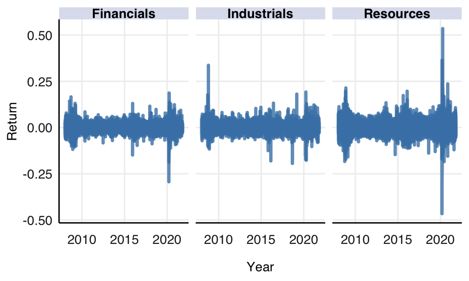

Figure 1: Returns by Sector

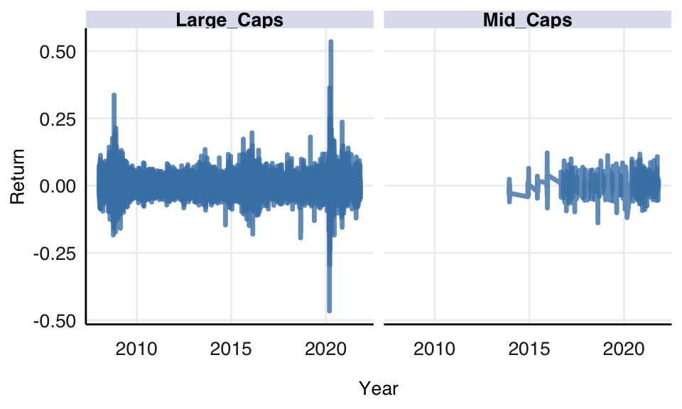

Figure 2: Returns by Size

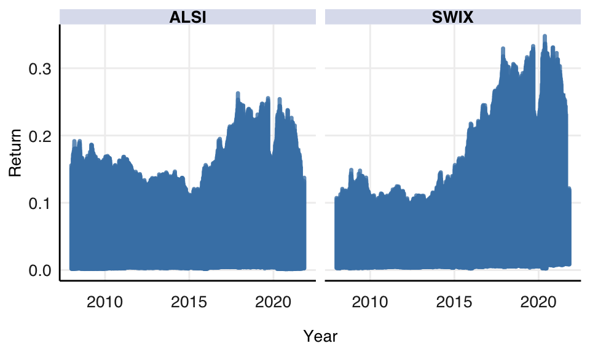

Figure 3: Returns by Index

# Stratification Analysis using USDZAR

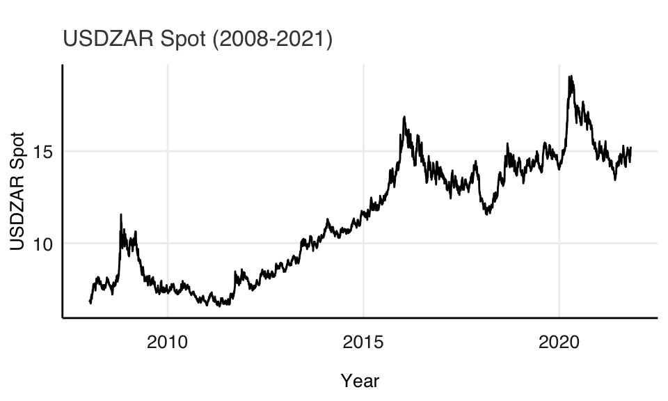

Figure 4: USDZAR Spot (2008-2021)

Table 1: Currency Volatility Months

| High_Volatility | Low Volatility |
| --- | --- |
| 2008December | 2008May |
| 2008November | 2010April |
| 2008October | 2010August |
| 2009January | 2010December |
| 2009March | 2010February |
| 2011September | 2010June |
| 2012May | 2010March |
| 2013May | 2010November |
| 2015December | 2010October |
| 2016April | 2011April |
| 2016August | 2011February |
| 2016February | 2011July |
| 2016January | 2011June |
| 2016June | 2011March |
| 2016May | 2012April |
| 2016November | 2012February |
| 2016September | 2012June |
| 2017April | 2012March |
| 2017December | 2012November |
| 2017March | 2012September |
| 2017October | 2013December |
| 2018August | 2013February |
| 2018June | 2013March |
| 2018September | 2013November |
| 2019January | 2013October |
| 2019June | 2014April |
| 2020April | 2014August |
| 2020August | 2014July |
| 2020March | 2014June |
| 2020May | 2014May |
| 2020November | 2015January |
| 2021June | 2018March |
| 2021September | 2019November |

Comparing the relative performance of the two indexes during periods of currency volatility (as specified above).

## Results

Table 2: Index Performance: High Volatility

| Index | SD | Full_SD | Period | Ratio |
| --- | --- | --- | --- | --- |
| SWIX | 0.79 | 0.68 | High_Vol | 1.16 |
| ALSI | 0.71 | 0.67 | High_Vol | 1.06 |

Table 3: Index Performance: Low Volatility

| Index | SD | Full_SD | Period | Ratio |
| --- | --- | --- | --- | --- |
| ALSI | 0.60 | 0.67 | Low_Vol | 0.89 |
| SWIX | 0.48 | 0.68 | Low_Vol | 0.71 |